# An introduction to smapr

Maxwell B. Joseph & Matthew Oakley

2016-10-04

In 2015 NASA launched the Soil Moisture Active Passive (SMAP) instrument, which measures global surface soil moisture and soil freeze-thaw conditions from space. The data are publicly available in HDF5 format via an FTP server hosted by the National Snow and Ice Data Center (NSIDC). The smapr package provides a suite of functions for programmatic discovery, download, exploration, and extraction of SMAP data.

Multiple SMAP data products are provided by the NSIDC, and these products vary in the amount of processing. Currently, smapr supports the more processed level 3 and level 4 data products, which represent global daily composite and global three hourly modeled data products, respectively. NSIDC provides documentation for all SMAP data products on their [website](https://nsidc.org/data/smap/smap-data.html), and we provide a summary of level 3 and level 4 products below.

### Supported SMAP data products

| Dataset id | Description | Resolution |
| --- | --- | --- |
| SPL3FTA | Radar Northern Hemisphere Daily Freeze/Thaw State | 3 km |
| SPL3SMA | Radar Global Daily Soil Moisture | 3 km |
| SPL3SMP | Radiometer Global Soil Moisture | 36 km |
| SPL3SMAP | Radar/Radiometer Global Soil Moisture | 9 km |
| SPL4SMAU | Surface/Rootzone Soil Moisture Analysis Update | 9 km |
| SPL4SMGP | Surface/Rootzone Soil Moisture Geophysical Data | 9 km |
| SPL4SMLM | Surface/Rootzone Soil Moisture Land Model Constants | 9 km |
| SPL4CMDL | Carbon Net Ecosystem Exchange | 9 km |

### Finding SMAP data

Data are hosted on an FTP server by the National Snow and Ice Data Center. The find_smap function searches for specific data products and returns a data frame of available data. As data mature and pass checks, versions advance. At any specific time, not all versions of all datasets for all dates may exist. For the most up to date overview of dataset versions, see the NSIDC SMAP data version [webpage](https://nsidc.org/data/smap/smap-data.html).

```r
library(smapr)
library(raster)
available_data <- find_smap(id = "SPL3SMAP", date = "2015-05-25", version = 3)
str(available_data)
```

```
## 'data.frame':    1 obs. of  3 variables:
##  $ name   : chr "SMAP_L3_SM_AP_20150525_R13080_001"
##  $ date   : Date, format: "2015-05-25"
##  $ ftp_dir: chr "SPL3SMAP.003/2015.05.25/"
```

### Downloading and inspecting SMAP data

Given a data frame produced by `find_smap`, `download_smap` downloads the data onto the local file system. Unless a directory is specified as an argument, the data are stored in the user’s cache.

```r
downloads <- download_smap(available_data)
str(downloads)
```

```
## 'data.frame':    1 obs. of  4 variables:
##  $ name     : chr "SMAP_L3_SM_AP_20150525_R13080_001"
##  $ date     : Date, format: "2015-05-25"
##  $ ftp_dir  : chr "SPL3SMAP.003/2015.05.25/"
##  $ local_dir: chr "/home/max/.cache/smap"
```

The SMAP data are provided in HDF5 format, and in any one file there are actually multiple data sets, including metadata. The `list_smap` function allows users to inspect the contents of downloaded data at a high level (`all = FALSE`) or in depth (`all = TRUE`).

```r
list_smap(downloads, all = FALSE)
```

```
## $SMAP_L3_SM_AP_20150525_R13080_001
##   group                         name     otype dclass dim
## 0     /                     Metadata H5I_GROUP
## 1     / Soil_Moisture_Retrieval_Data H5I_GROUP
```

```r
list_smap(downloads, all = TRUE)
```

```
## $SMAP_L3_SM_AP_20150525_R13080_001
##                                  group                             name
## 0                                    /                         Metadata
## 1                            /Metadata           AcquisitionInformation
## 2     /Metadata/AcquisitionInformation                         platform
## 3     /Metadata/AcquisitionInformation                 platformDocument
## 4     /Metadata/AcquisitionInformation                            radar
## 5     /Metadata/AcquisitionInformation                    radarDocument
## 6     /Metadata/AcquisitionInformation                       radiometer
## 7     /Metadata/AcquisitionInformation               radiometerDocument
## 8                            /Metadata                      DataQuality
## 9                /Metadata/DataQuality             CompletenessOmission
## 10               /Metadata/DataQuality                DomainConsistency
## 11                           /Metadata            DatasetIdentification
## 12                           /Metadata                           Extent
```

[output cut: 120 more lines]

### Extracting gridded data products

The `extract_smap` function extracts gridded data products (e.g., global soil moisture) and returns Raster* objects with the proper spatial projections etc. If more than one file has been downloaded and passed into the first argument, `extract_smap` extracts all of the rasters and returns a RasterStack.

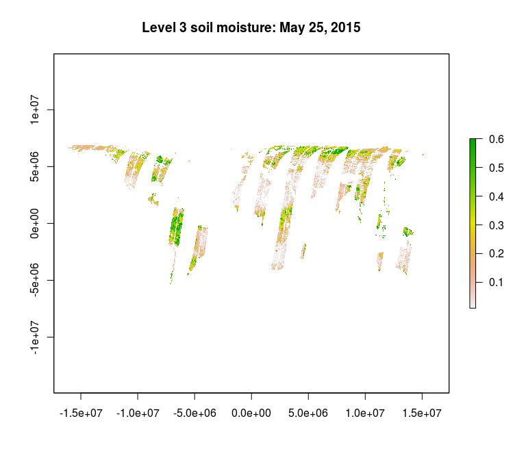

```r
sm_raster <- extract_smap(downloads, "Soil_Moisture_Retrieval_Data/soil_moisture")
plot(sm_raster, main = "Level 3 soil moisture: May 25, 2015")
```

## Saving GeoTIFF output

The raster stack can be saved as a GeoTIFF using the `writeRaster` function from the raster pacakge.

```r
writeRaster(sm_raster, "wgs84_ft.tif")
```

Bug reports, issues, and feature requests can be submitted via GitHub: https://github.com/mbjoseph/smapr